# ScGl_demography_BLM

Michelle DePrenger-Levin

Monday, October 05, 2015

The repository is named “ScGl”  
Will need: git push ScGl master

2015: uploaded “Q:/Research/All_Projects_by_Species/Sclerocactus SPECIES/Sclerocactus_glaucus/Raw Data/2015 Datasheets/DataEntry2015_10.13.15.csv”

Need 2008 data seperate from the MySQL database due to lack of measuring hight and width. Will need to get length tagged individuals for number alive instead of number of individuals with a heigth/width in later years. https://research.botanicgardens.org/admin/

In 2012 we switched from measuring the height and width indiviudals under 0.5 cm in width to counting them as “minis”.

```r
scgl08 <- read.delim(path.expand("Q:/Research/All_Projects_by_Species/Sclerocactus SPECIES/Sclerocactus_glaucus/R_code_ScGl/R_tables/All2008.txt"),sep=",")

head(scgl08)
```

```
##   Year         SiteName Transect CountofHeight CountofWidth SumFlowered
## 1 2008 Escalante Canyon     0.17             2            2           0
## 2 2008 Escalante Canyon    11.10             5            5           1
## 3 2008 Escalante Canyon    12.10             4            4           1
## 4 2008 Escalante Canyon    17.79            12           12           9
## 5 2008 Escalante Canyon    22.26             2            2           2
## 6 2008 Escalante Canyon    23.26             1            1           0
##   SumBrowsed PlotArea SumOfMinis JanRain FebRain MarRain AplRain MayRain
## 1          0       20         NA    72.4   58.55   21.49   33.88   49.18
## 2          0       20         NA    72.4   58.55   21.49   33.88   49.18
## 3          0       20         NA    72.4   58.55   21.49   33.88   49.18
## 4          0       20         NA    72.4   58.55   21.49   33.88   49.18
## 5          0       20         NA    72.4   58.55   21.49   33.88   49.18
## 6          0       20         NA    72.4   58.55   21.49   33.88   49.18
##   JunRain JulRain AugRain SeptRain OctRain NovRain DecRain
```

[output cut: 27 more lines]

```r
scgl08_2 <- data.frame(scgl08[,c(1:3)], AverageHeight = as.numeric(NA), AverageWidth = as.numeric(NA),
        scgl08[,c(4:8)],
            Minis = as.numeric(scgl08[,9]), scgl08[,c(10:12)],
            AprRain = scgl08[,c(13)], scgl08[,c(14:21)],
            PrYrRain = scgl08[,c(22)], scgl08[,c(23:34)])
str(scgl08_2)
```

```
## 'data.frame':    17 obs. of  36 variables:
##  $ Year         : int  2008 2008 2008 2008 2008 2008 2008 2008 2008 2008 ...
##  $ SiteName     : Factor w/ 4 levels "Escalante Canyon",..: 1 1 1 1 1 1 1 1 2 2 ...
##  $ Transect     : num  0.17 11.1 12.1 17.79 22.26 ...
##  $ AverageHeight: num  NA NA NA NA NA NA NA NA NA NA ...
##  $ AverageWidth : num  NA NA NA NA NA NA NA NA NA NA ...
##  $ CountofHeight: int  2 5 4 12 2 1 4 2 8 9 ...
##  $ CountofWidth : int  2 5 4 12 2 1 4 2 8 9 ...
##  $ SumFlowered  : num  0 1 1 9 2 0 3 0 3 4 ...
##  $ SumBrowsed   : num  0 0 0 0 0 0 0 0 0 0 ...
##  $ PlotArea     : num  20 20 20 20 20 20 20 20 20 20 ...
##  $ Minis        : num  NA NA NA NA NA NA NA NA NA NA ...
##  $ JanRain      : num  72.4 72.4 72.4 72.4 72.4 ...
##  $ FebRain      : num  58.5 58.5 58.5 58.5 58.5 ...
##  $ MarRain      : num  21.5 21.5 21.5 21.5 21.5 ...
```

[output cut: 22 more lines]

```r
head(scgl08_2)
```

```
##   Year         SiteName Transect AverageHeight AverageWidth CountofHeight
## 1 2008 Escalante Canyon     0.17            NA           NA             2
## 2 2008 Escalante Canyon    11.10            NA           NA             5
## 3 2008 Escalante Canyon    12.10            NA           NA             4
## 4 2008 Escalante Canyon    17.79            NA           NA            12
## 5 2008 Escalante Canyon    22.26            NA           NA             2
## 6 2008 Escalante Canyon    23.26            NA           NA             1
##   CountofWidth SumFlowered SumBrowsed PlotArea Minis JanRain FebRain
## 1            2           0          0       20    NA    72.4   58.55
## 2            5           1          0       20    NA    72.4   58.55
## 3            4           1          0       20    NA    72.4   58.55
## 4           12           9          0       20    NA    72.4   58.55
## 5            2           2          0       20    NA    72.4   58.55
## 6            1           0          0       20    NA    72.4   58.55
##   MarRain AprRain MayRain JunRain JulRain AugRain SeptRain OctRain NovRain
```

[output cut: 27 more lines]

```r
names(scgl08_2)
```

```
##  [1] "Year"          "SiteName"      "Transect"      "AverageHeight"
##  [5] "AverageWidth"  "CountofHeight" "CountofWidth"  "SumFlowered"
##  [9] "SumBrowsed"    "PlotArea"      "Minis"         "JanRain"
## [13] "FebRain"       "MarRain"       "AprRain"       "MayRain"
## [17] "JunRain"       "JulRain"       "AugRain"       "SeptRain"
## [21] "OctRain"       "NovRain"       "DecRain"       "PrYrRain"
## [25] "JanMaxTemp"    "FebMaxTemp"    "MarMaxTemp"    "AprMaxTemp"
## [29] "MayMaxTemp"    "JunMaxTemp"    "JulMaxTemp"    "AugMaxTemp"
## [33] "SeptMaxTemp"   "OctMaxTemp"    "NovMaxTemp"    "DecMaxTemp"
```

2008-2015 data ### Need to update after upload process fixed

```r
rm(sg)
#sg <- read.csv(path.expand("P:/hackathon/ScGl/2015_ScGl_rawdata_witherrors.csv"))
#sg <- read.csv(path.expand("P:/hackathon/ScGl/2015_ScGl_rawdata_102915.csv"))
#sg <- read.csv(path.expand("Q:/Research/All_Projects_by_Species/Sclerocactus SPECIES/Sclerocactus_glaucus/Excel/2015_ScGl/RawData_scgl_2015_102915.csv"))
sg <- read.csv(path.expand("P:/hackathon/ScGl/RawData_scgl_2015_103015.csv"))

head(sg)
```

```
##   ScGl_data_id Site Year    Tag Transect X.coord.m. Y.coord.m. Degrees
## 1         2893      2012     NA                  NA         NA      NA
## 2         2892      2012     NA                  NA         NA      NA
## 3         2085      2010 237.00                  NA         NA      NA
## 4         2083      2011 237.00                  NA         NA      NA
## 5         2084      2012 237.00                  NA         NA      NA
## 6         2087      2010 237.01                  NA         NA      NA
##   Direction Height.cm. Width.cm. Fl Br Minis PhotoNumber         Comments
## 1        NA        8.1       6.5  y  n    NA
## 2        NA        5.2       4.9  y  n    NA
## 3        NA        5.3       6.7  y  n    NA        2815 solitary - to SW
## 4        NA        8.7       6.3  y  n    NA        3951
## 5        NA        8.1       6.4  y  n    NA
## 6        NA        6.1       5.3  y  n    NA        2816  closest to nail
##   X_coord_old Y_coord_old
## 1        0.70        22.1
## 2        0.10        14.1
## 3        2.75         1.0
## 4        2.75         1.0
## 5        2.75         1.0
## 6        2.75         1.0
```

```r
names(sg)
```

```
##  [1] "ScGl_data_id" "Site"         "Year"         "Tag"
##  [5] "Transect"     "X.coord.m."   "Y.coord.m."   "Degrees"
##  [9] "Direction"    "Height.cm."   "Width.cm."    "Fl"
## [13] "Br"           "Minis"        "PhotoNumber"  "Comments"
## [17] "X_coord_old"  "Y_coord_old"
```

```r
table(sg$Site,sg$Year) #Are all the data lacking site information from Road T-East?
```

```
##
##                     2008 2009 2010 2011 2012 2013 2014 2015
##                        0    0   19   19   21    0    0    0
##   Atwell Gulch_108     0   59   64  107  217  238  246  286
##   Atwell Gulch_165     0   75   86  133  150   98  113  179
##   Bridgeport           0    0    0   19   20   24   23   32
##   Escalante Canyon    32   41   48   50   59   70   77  108
##   Fram                 0    0    0    0    0  125  135    0
##   Oil Pad              0    0    0    0   67   92  108  126
##   Oil Pad (old)        0    0   29   31   49   58   64   67
##   Picnic Site         50   77   90   97  120  121  134  177
##   Pond                 0    0    0    0  300  324  338  246
##   Pond (old)           0    0   76  107   97   61   81   23
##   Powerline           37   38   41   44   44   46   48   52
##   Pyramid Rock        66  102  138  158  164  176  166  221
##   Road T-East (old)    0    0    0    0    1    0    0    0
##   Road T-West (old)    0    0   42   60  104  122  184  236
##   T-Junction           0    0    0    0   41   65  119  139
```

```r
#Remove rows where Site is blank, if any
if(nrow(sg[-which(sg$Site == ""),])>0){
  sg <- sg[-which(sg$Site == ""),]
  }


sg$Vol <- pi*(sg$Width.cm.^2)*sg$Height.cm.

nrow(sg[sg$Year == 2008,])
```

```
## [1] 185
```

## Summarize old and new data by number of individuals

Need to split by Site - Atwell Gulch needs to be together:  
`Atwell Gulch_108` and `Atwell Gulch_165` are Atwell Gulch with Ycoord < 30 Road T-West (old) vs. T-Junction Oil Pad and Oil Pad (old) Pond and Pond (old)

merge datasets  
2008:

```r
table(scgl08_2$SiteName)  #summarized number of plants per plot per site
```

```
##
## Escalante Canyon      Picnic Site        Powerline     Pyramid Rock
##                8                5                2                2
```

```r
table(sg$Site)
```

```
##
##                    Atwell Gulch_108  Atwell Gulch_165        Bridgeport
##                 0              1217               834               118
##  Escalante Canyon              Fram           Oil Pad     Oil Pad (old)
##               485               260               393               298
##       Picnic Site              Pond        Pond (old)         Powerline
##               866              1208               445               350
##      Pyramid Rock Road T-East (old) Road T-West (old)        T-Junction
##              1191                 1               748               364
```

```r
head(scgl08_2[,c("SiteName","Year","Transect")])
```

```
##           SiteName Year Transect
## 1 Escalante Canyon 2008     0.17
## 2 Escalante Canyon 2008    11.10
## 3 Escalante Canyon 2008    12.10
## 4 Escalante Canyon 2008    17.79
## 5 Escalante Canyon 2008    22.26
## 6 Escalante Canyon 2008    23.26
```

```r
head(scgl08_2)
```

```
##   Year         SiteName Transect AverageHeight AverageWidth CountofHeight
## 1 2008 Escalante Canyon     0.17            NA           NA             2
## 2 2008 Escalante Canyon    11.10            NA           NA             5
## 3 2008 Escalante Canyon    12.10            NA           NA             4
## 4 2008 Escalante Canyon    17.79            NA           NA            12
## 5 2008 Escalante Canyon    22.26            NA           NA             2
## 6 2008 Escalante Canyon    23.26            NA           NA             1
##   CountofWidth SumFlowered SumBrowsed PlotArea Minis JanRain FebRain
## 1            2           0          0       20    NA    72.4   58.55
## 2            5           1          0       20    NA    72.4   58.55
## 3            4           1          0       20    NA    72.4   58.55
## 4           12           9          0       20    NA    72.4   58.55
## 5            2           2          0       20    NA    72.4   58.55
## 6            1           0          0       20    NA    72.4   58.55
##   MarRain AprRain MayRain JunRain JulRain AugRain SeptRain OctRain NovRain
```

[output cut: 27 more lines]

```r
sg$Fl <- as.numeric(sg$Fl)
sg$Br <- as.numeric(sg$Br)
str(sg)
```

```
## 'data.frame':    8778 obs. of  19 variables:
##  $ ScGl_data_id: int  1105 1103 1104 1102 6075 7748 9613 1109 1106 1108 ...
##  $ Site        : Factor w/ 16 levels "","Atwell Gulch_108",..: 2 2 2 2 2 2 2 2 2 2 ...
##  $ Year        : int  2009 2010 2011 2012 2013 2014 2015 2009 2010 2011 ...
##  $ Tag         : num  185 185 185 185 185 ...
##  $ Transect    : Factor w/ 81 levels "","0.17","1",..: 43 43 43 43 43 43 43 43 43 43 ...
##  $ X.coord.m.  : num  0.1 0.1 0.1 0.1 0.1 0.1 0.1 0.1 0.1 0.1 ...
##  $ Y.coord.m.  : num  6.63 6.63 6.63 6.63 6.63 6.63 6.63 6.63 6.63 6.63 ...
##  $ Degrees     : int  NA NA NA NA NA NA NA NA NA NA ...
##  $ Direction   : num  NA NA NA NA NA NA NA NA NA NA ...
##  $ Height.cm.  : num  8.2 9.5 7.7 6.5 7.6 8.1 9.2 2.9 2.7 2.1 ...
##  $ Width.cm.   : num  10.3 8.3 9 8.1 8.3 9.5 9.6 4.2 3.6 4.2 ...
##  $ Fl          : num  3 3 3 3 3 3 3 2 3 3 ...
##  $ Br          : num  2 2 2 2 2 2 2 2 2 2 ...
##  $ Minis       : int  NA NA NA NA NA 1 2 NA NA NA ...
##  $ PhotoNumber : Factor w/ 1382 levels "","-5766","(5404) 524",..: 179 1315 733 1 1 1 1 1 1316 733 ...
##  $ Comments    : Factor w/ 996 levels ""," dying/dead",..: 611 730 1 1 251 1 1 302 1 1 ...
##  $ X_coord_old : num  0 0 0 0 0 0 0 0 0 0 ...
##  $ Y_coord_old : num  0 0 0 0 0 0 0 0 0 0 ...
##  $ Vol         : num  2733 2056 1959 1340 1645 ...
```

```r
sg$Fl[sg$Fl == 1] <- 0
sg$Fl[sg$Fl == 2] <- 0
sg$Fl[sg$Fl == 3] <- 1

sg$Br[sg$Br == 1] <- 0
sg$Br[sg$Br == 2] <- 0
sg$Br[sg$Br == 3] <- 1

str(sg)
```

```
## 'data.frame':    8778 obs. of  19 variables:
##  $ ScGl_data_id: int  1105 1103 1104 1102 6075 7748 9613 1109 1106 1108 ...
##  $ Site        : Factor w/ 16 levels "","Atwell Gulch_108",..: 2 2 2 2 2 2 2 2 2 2 ...
##  $ Year        : int  2009 2010 2011 2012 2013 2014 2015 2009 2010 2011 ...
##  $ Tag         : num  185 185 185 185 185 ...
##  $ Transect    : Factor w/ 81 levels "","0.17","1",..: 43 43 43 43 43 43 43 43 43 43 ...
##  $ X.coord.m.  : num  0.1 0.1 0.1 0.1 0.1 0.1 0.1 0.1 0.1 0.1 ...
##  $ Y.coord.m.  : num  6.63 6.63 6.63 6.63 6.63 6.63 6.63 6.63 6.63 6.63 ...
##  $ Degrees     : int  NA NA NA NA NA NA NA NA NA NA ...
##  $ Direction   : num  NA NA NA NA NA NA NA NA NA NA ...
##  $ Height.cm.  : num  8.2 9.5 7.7 6.5 7.6 8.1 9.2 2.9 2.7 2.1 ...
##  $ Width.cm.   : num  10.3 8.3 9 8.1 8.3 9.5 9.6 4.2 3.6 4.2 ...
##  $ Fl          : num  1 1 1 1 1 1 1 0 1 1 ...
##  $ Br          : num  0 0 0 0 0 0 0 0 0 0 ...
##  $ Minis       : int  NA NA NA NA NA 1 2 NA NA NA ...
##  $ PhotoNumber : Factor w/ 1382 levels "","-5766","(5404) 524",..: 179 1315 733 1 1 1 1 1 1316 733 ...
##  $ Comments    : Factor w/ 996 levels ""," dying/dead",..: 611 730 1 1 251 1 1 302 1 1 ...
##  $ X_coord_old : num  0 0 0 0 0 0 0 0 0 0 ...
##  $ Y_coord_old : num  0 0 0 0 0 0 0 0 0 0 ...
##  $ Vol         : num  2733 2056 1959 1340 1645 ...
```

# Old and New data

Atwell Gulch old is everything with a Y less than 30  
Atwell Gulch new is everything Atwell Gulch

```r
head(sg[grep("Atwell",sg$Site),])
```

```
##    ScGl_data_id             Site Year Tag Transect X.coord.m. Y.coord.m.
## 60         1105 Atwell Gulch_108 2009 185      2.4        0.1       6.63
## 61         1103 Atwell Gulch_108 2010 185      2.4        0.1       6.63
## 62         1104 Atwell Gulch_108 2011 185      2.4        0.1       6.63
## 63         1102 Atwell Gulch_108 2012 185      2.4        0.1       6.63
## 64         6075 Atwell Gulch_108 2013 185      2.4        0.1       6.63
## 65         7748 Atwell Gulch_108 2014 185      2.4        0.1       6.63
##    Degrees Direction Height.cm. Width.cm. Fl Br Minis PhotoNumber
## 60      NA        NA        8.2      10.3  1  0    NA  1605, 1606
## 61      NA        NA        9.5       8.3  1  0    NA         900
## 62      NA        NA        7.7       9.0  1  0    NA        3800
## 63      NA        NA        6.5       8.1  1  0    NA
## 64      NA        NA        7.6       8.3  1  0    NA
## 65      NA        NA        8.1       9.5  1  0     1
##                                Comments X_coord_old Y_coord_old      Vol
## 60 largest of 3; also photos 1607, 1608           0           0 2732.991
## 61                           No tag 186           0           0 2056.031
## 62                                                0           0 1959.411
## 63                                                0           0 1339.779
## 64                                9 o'c           0           0 1644.825
## 65                                                0           0 2296.583
```

```r
ag_old <- subset(sg[grep("Atwell",sg$Site),], Y.coord.m. < 30)
table(ag_old$Site)
```

```
##
##                    Atwell Gulch_108  Atwell Gulch_165        Bridgeport
##                 0               979               834                 0
##  Escalante Canyon              Fram           Oil Pad     Oil Pad (old)
##                 0                 0                 0                 0
##       Picnic Site              Pond        Pond (old)         Powerline
##                 0                 0                 0                 0
##      Pyramid Rock Road T-East (old) Road T-West (old)        T-Junction
##                 0                 0                 0                 0
```

```r
ag_new <- sg[intersect(grep("Atwell",sg$Site),which(sg$Year>2011)),]

head(ag_new)
```

```
##    ScGl_data_id             Site Year    Tag Transect X.coord.m.
## 63         1102 Atwell Gulch_108 2012 185.00      2.4        0.1
## 64         6075 Atwell Gulch_108 2013 185.00      2.4        0.1
## 65         7748 Atwell Gulch_108 2014 185.00      2.4        0.1
## 66         9613 Atwell Gulch_108 2015 185.00      2.4        0.1
## 70         1107 Atwell Gulch_108 2012 185.01      2.4        0.1
## 71         6076 Atwell Gulch_108 2013 185.01      2.4        0.1
##    Y.coord.m. Degrees Direction Height.cm. Width.cm. Fl Br Minis
## 63       6.63      NA        NA        6.5       8.1  1  0    NA
## 64       6.63      NA        NA        7.6       8.3  1  0    NA
## 65       6.63      NA        NA        8.1       9.5  1  0     1
## 66       6.63      NA        NA        9.2       9.6  1  0     2
## 70       6.63      NA        NA        2.6       3.9  1  0    NA
## 71       6.63      NA        NA        4.0       4.3  1  0    NA
##    PhotoNumber Comments X_coord_old Y_coord_old       Vol
## 63                                0           0 1339.7793
## 64                9 o'c           0           0 1644.8248
## 65                                0           0 2296.5828
## 66                                0           0 2663.6684
## 70                                0           0  124.2374
## 71                6 o'c           0           0  232.3522
```

```
## stat_bin: binwidth defaulted to range/30. Use 'binwidth = x' to adjust this.
```

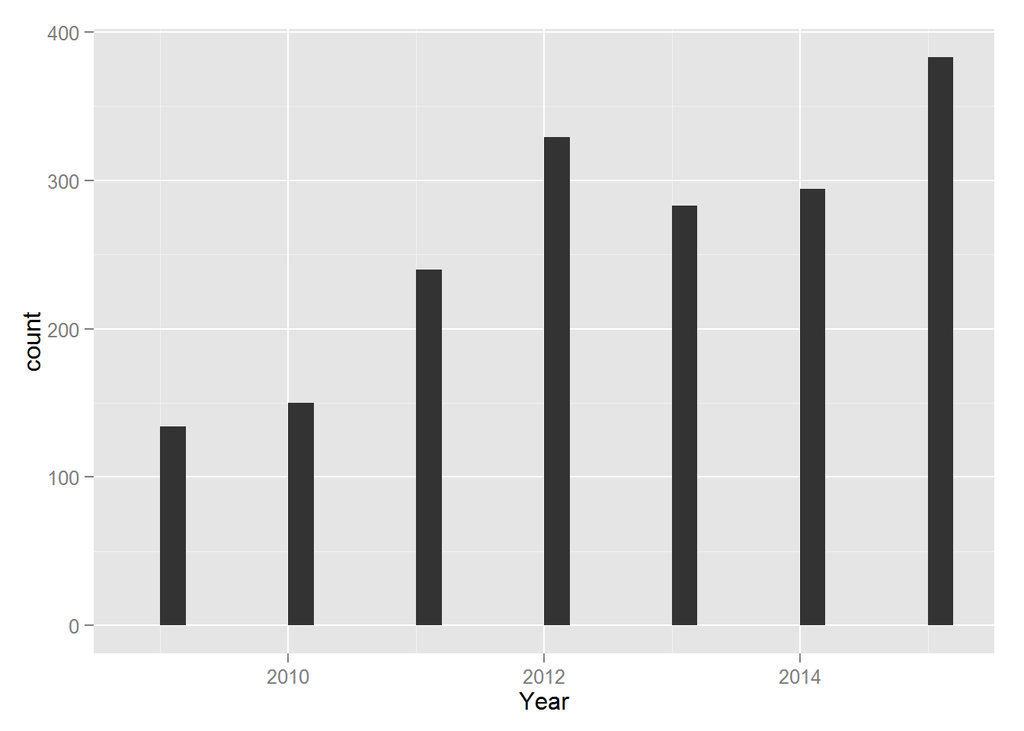

```r
ggplot(ag_old, aes(Year))+
  geom_histogram()
```

```
## stat_bin: binwidth defaulted to range/30. Use 'binwidth = x' to adjust this.
```

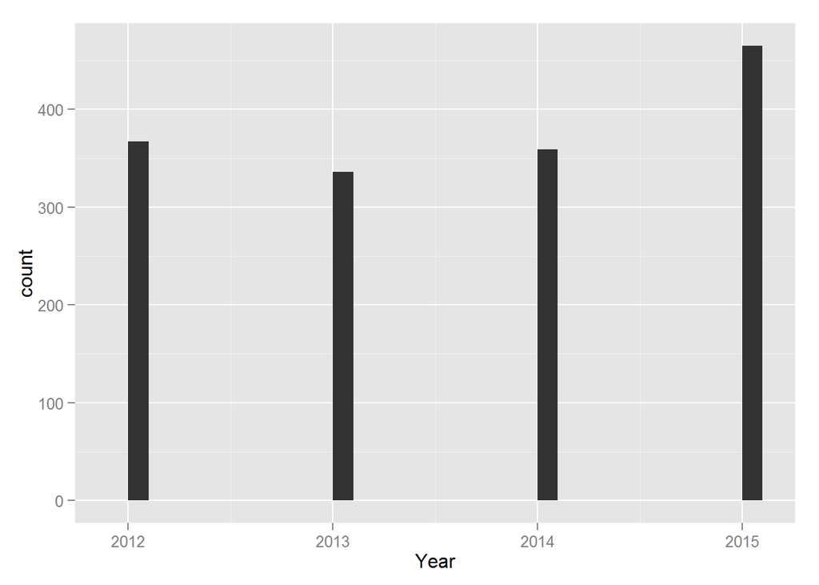

```r
ggplot(ag_new, aes(Year))+
  geom_histogram()
```

```r
# This is repetative from at_old and at_new
# Rename Sites for Atwell old and new

# Add a level to the Site factor field
levels(sg$Site) <- c(levels(sg$Site), "Atwell Gulch", "Atwell Gulch (old)")

atwell <- sg[intersect(grep("Atwell",sg$Site),which(sg$Year>2011)),]
unique(atwell$Year)
```

```
## [1] 2012 2013 2014 2015
```

```r
atwell$Site <- "Atwell Gulch"

atwell_old <- sg[intersect(grep("Atwell",sg$Site),which(atwell$Y.coord.m.<30)),]
unique(atwell_old$Year)
```

```
## [1] 2009 2010 2011 2012 2013 2014 2015
```

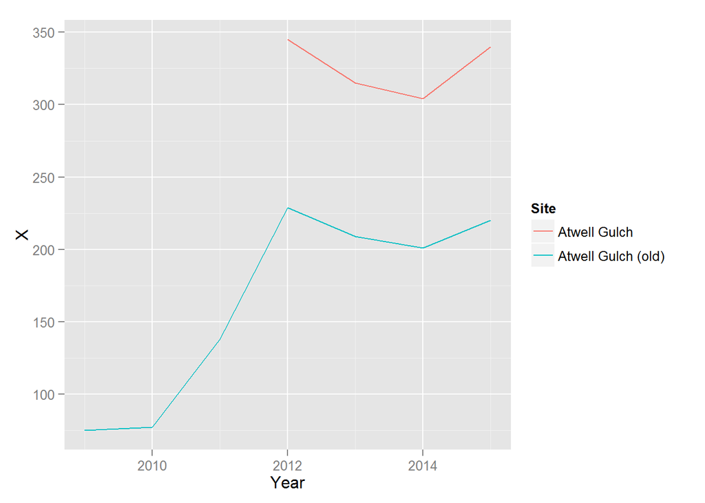

```r
atwell_old$Site <- "Atwell Gulch (old)"

atwell.all <- rbind(atwell_old, atwell)

# don't want to do this, want to do after combine again with sg so we have old and new Atwell
atwell_summary <- ddply(subset(atwell.all, Height.cm. > 0),
                           .(Site,Year),
                    summarise,
                X = length(Tag),
                Rep = sum(Fl),
                Brs = sum(Br),
                avgH = mean(Height.cm., na.rm = TRUE),
                sdH = sd(Height.cm., na.rm = TRUE),
                avgW = mean(Width.cm., na.rm = TRUE),
                avgVol = mean(Vol, na.rm = TRUE),
                sdVol = sd(Vol, na.rm = TRUE))

ggplot(atwell_summary, aes(Year,X,colour=Site))+
  geom_line()
```

2008 is a summary already, need to summarize rest before combining with 2008.

```r
#Exclude Atwell
sgNotatwell <- sg[grep("Atwell", sg$Site, invert=TRUE),]
table(sgNotatwell$Site,sgNotatwell$Year)
```

```
##
##                      2008 2009 2010 2011 2012 2013 2014 2015
##                         0    0    0    0    0    0    0    0
##   Atwell Gulch_108      0    0    0    0    0    0    0    0
##   Atwell Gulch_165      0    0    0    0    0    0    0    0
##   Bridgeport            0    0    0   19   20   24   23   32
##   Escalante Canyon     32   41   48   50   59   70   77  108
##   Fram                  0    0    0    0    0  125  135    0
##   Oil Pad               0    0    0    0   67   92  108  126
##   Oil Pad (old)         0    0   29   31   49   58   64   67
##   Picnic Site          50   77   90   97  120  121  134  177
##   Pond                  0    0    0    0  300  324  338  246
##   Pond (old)            0    0   76  107   97   61   81   23
##   Powerline            37   38   41   44   44   46   48   52
##   Pyramid Rock         66  102  138  158  164  176  166  221
##   Road T-East (old)     0    0    0    0    1    0    0    0
##   Road T-West (old)     0    0   42   60  104  122  184  236
##   T-Junction            0    0    0    0   41   65  119  139
##   Atwell Gulch          0    0    0    0    0    0    0    0
##   Atwell Gulch (old)    0    0    0    0    0    0    0    0
```

```r
noEast <- sgNotatwell[grep("Road T-East", sgNotatwell$Site, invert=TRUE),]
table(noEast$Site,noEast$Year)
```

```
##
##                      2008 2009 2010 2011 2012 2013 2014 2015
##                         0    0    0    0    0    0    0    0
##   Atwell Gulch_108      0    0    0    0    0    0    0    0
##   Atwell Gulch_165      0    0    0    0    0    0    0    0
##   Bridgeport            0    0    0   19   20   24   23   32
##   Escalante Canyon     32   41   48   50   59   70   77  108
##   Fram                  0    0    0    0    0  125  135    0
##   Oil Pad               0    0    0    0   67   92  108  126
##   Oil Pad (old)         0    0   29   31   49   58   64   67
##   Picnic Site          50   77   90   97  120  121  134  177
##   Pond                  0    0    0    0  300  324  338  246
##   Pond (old)            0    0   76  107   97   61   81   23
##   Powerline            37   38   41   44   44   46   48   52
##   Pyramid Rock         66  102  138  158  164  176  166  221
##   Road T-East (old)     0    0    0    0    0    0    0    0
##   Road T-West (old)     0    0   42   60  104  122  184  236
##   T-Junction            0    0    0    0   41   65  119  139
##   Atwell Gulch          0    0    0    0    0    0    0    0
##   Atwell Gulch (old)    0    0    0    0    0    0    0    0
```

```r
#bind new and old Atwell to sg
sg_all <- rbind(noEast,atwell,atwell_old)
table(sg_all$Site,sg_all$Year)
```

```
##
##                      2008 2009 2010 2011 2012 2013 2014 2015
##                         0    0    0    0    0    0    0    0
##   Atwell Gulch_108      0    0    0    0    0    0    0    0
##   Atwell Gulch_165      0    0    0    0    0    0    0    0
##   Bridgeport            0    0    0   19   20   24   23   32
##   Escalante Canyon     32   41   48   50   59   70   77  108
##   Fram                  0    0    0    0    0  125  135    0
##   Oil Pad               0    0    0    0   67   92  108  126
##   Oil Pad (old)         0    0   29   31   49   58   64   67
##   Picnic Site          50   77   90   97  120  121  134  177
##   Pond                  0    0    0    0  300  324  338  246
##   Pond (old)            0    0   76  107   97   61   81   23
##   Powerline            37   38   41   44   44   46   48   52
##   Pyramid Rock         66  102  138  158  164  176  166  221
##   Road T-East (old)     0    0    0    0    0    0    0    0
##   Road T-West (old)     0    0   42   60  104  122  184  236
##   T-Junction            0    0    0    0   41   65  119  139
##   Atwell Gulch          0    0    0    0  367  336  359  465
##   Atwell Gulch (old)    0   75   77  138  238  221  236  304
```

```r
str(sg_all)
```

```
## 'data.frame':    9542 obs. of  19 variables:
##  $ ScGl_data_id: int  11166 2668 2667 6383 10035 2662 2661 6381 8074 10031 ...
##  $ Site        : Factor w/ 18 levels "","Atwell Gulch_108",..: 4 4 4 4 4 4 4 4 4 4 ...
##  $ Year        : int  2015 2011 2012 2013 2015 2011 2012 2013 2014 2015 ...
##  $ Tag         : num  447 772 772 772 772 780 780 780 780 780 ...
##  $ Transect    : Factor w/ 81 levels "","0.17","1",..: 3 3 3 3 3 3 3 3 3 3 ...
##  $ X.coord.m.  : num  0.33 0.23 0.23 0.23 0.23 0.48 0.48 0.48 0.48 0.48 ...
##  $ Y.coord.m.  : num  6.82 36.38 36.38 36.38 36.38 ...
##  $ Degrees     : int  NA NA NA NA NA NA NA NA NA NA ...
##  $ Direction   : num  NA NA NA NA NA NA NA NA NA NA ...
##  $ Height.cm.  : num  2.3 4.3 2.9 0 0 3.9 2.9 1.2 0 0 ...
##  $ Width.cm.   : num  2 5.9 4.9 0 0 5.8 4.9 4.8 0 0 ...
##  $ Fl          : num  0 1 1 0 0 1 1 0 0 0 ...
##  $ Br          : num  0 0 0 0 0 0 0 1 0 0 ...
##  $ Minis       : int  NA NA NA NA NA NA NA NA NA NA ...
##  $ PhotoNumber : Factor w/ 1382 levels "","-5766","(5404) 524",..: 1 651 1 1 1 646 1 1152 1152 1 ...
##  $ Comments    : Factor w/ 996 levels ""," dying/dead",..: 1 1 1 406 405 1 1 1 431 405 ...
##  $ X_coord_old : num  0 0 0 0 0 0 0 0 0 0 ...
##  $ Y_coord_old : num  0 0 0 0 0 0 0 0 0 0 ...
##  $ Vol         : num  28.9 470.2 218.7 0 0 ...
```

```r
sg_all$Vol
```

[output not shown]

[output cut: 1894 more lines]

```r
#Reset to factor remaining Sites
sg_all$Site <- factor(sg_all$Site)

# All sites
sg_summary <- ddply(sg_all,
                    .(Site,Year), summarise,
                    X = length(Tag[Height.cm. > 0]),
                    Rep = sum(Fl),
                    Brs = sum(Br),
                    avgH = mean(Height.cm.[Height.cm. > 0], na.rm = TRUE),
                    sdH = sd(Height.cm.[Height.cm. > 0], na.rm = TRUE),
                    avgW = mean(Width.cm.[Width.cm. > 0], na.rm = TRUE),
                    sdW = sd(Width.cm.[Width.cm. > 0], na.rm = TRUE),
                    avgVol = mean(Vol, na.rm = TRUE),
                    sdVol = sd(Vol, na.rm = TRUE))

head(sg_summary)
```

```
##               Site Year  X Rep Brs     avgH       sdH     avgW      sdW
## 1       Bridgeport 2011 19  15   0 3.652632 1.2513852 4.657895 1.340943
## 2       Bridgeport 2012 20  18   0 2.845000 1.0143575 4.115000 1.189106
## 3       Bridgeport 2013 13   4   1 2.307692 1.5580231 3.138462 1.890564
## 4       Bridgeport 2014  8   3   0 2.987500 0.9538456 3.150000 1.800793
## 5       Bridgeport 2015 13   3   0 3.323077 1.1519215 2.869231 1.567580
## 6 Escalante Canyon 2008 32  16   0      NaN        NA      NaN       NA
##      avgVol    sdVol
## 1 289.07844 205.4785
## 2 182.84101 123.7916
## 3  74.02037 159.3593
## 4  50.44087 120.6438
## 5  52.28828 109.6078
## 6       NaN       NA
```

```r
table(sg_summary$Site,sg_summary$Year)
```

```
##
##                      2008 2009 2010 2011 2012 2013 2014 2015
##   Bridgeport            0    0    0    1    1    1    1    1
##   Escalante Canyon      1    1    1    1    1    1    1    1
##   Fram                  0    0    0    0    0    1    1    0
##   Oil Pad               0    0    0    0    1    1    1    1
##   Oil Pad (old)         0    0    1    1    1    1    1    1
##   Picnic Site           1    1    1    1    1    1    1    1
##   Pond                  0    0    0    0    1    1    1    1
##   Pond (old)            0    0    1    1    1    1    1    1
##   Powerline             1    1    1    1    1    1    1    1
##   Pyramid Rock          1    1    1    1    1    1    1    1
##   Road T-West (old)     0    0    1    1    1    1    1    1
##   T-Junction            0    0    0    0    1    1    1    1
##   Atwell Gulch          0    0    0    0    1    1    1    1
##   Atwell Gulch (old)    0    1    1    1    1    1    1    1
```

```r
#Missing half of Pond data, need to remove for 2015
sg_sum <- sg_summary[-which(grepl("Pond", sg_summary$Site)&sg_summary$Year == 2015) ,]
```

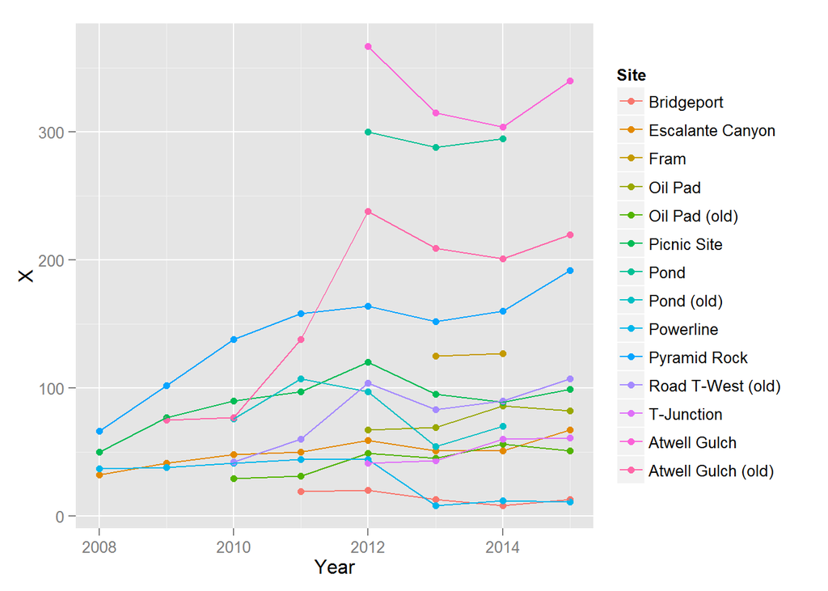

```r
ggplot(sg_sum, aes(Year,X,colour=Site))+
  geom_point()+
  geom_line()
```

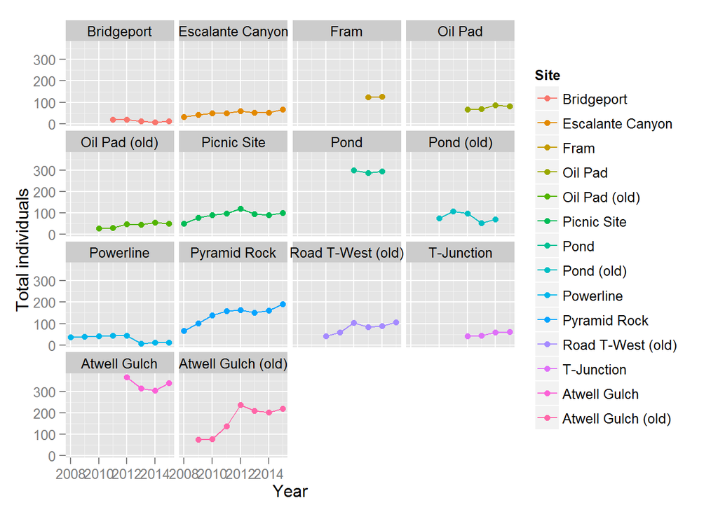

```r
ggplot(sg_sum, aes(Year,X,colour=Site))+
  geom_point()+
  geom_line()+
  facet_wrap(~Site)+
  ylab("Total individuals")
```

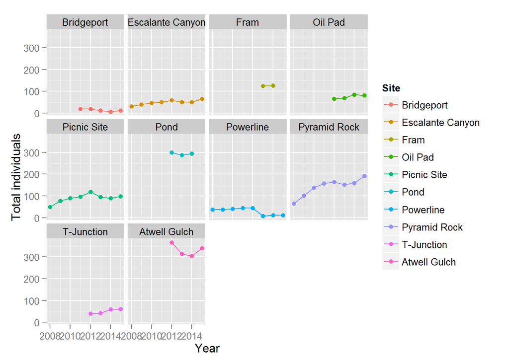

```r
# All the new ones
ggplot(sg_sum[grep("old",sg_sum$Site,invert=TRUE),], aes(Year,X,colour=Site))+
  geom_point()+
  geom_line()+
  facet_wrap(~Site)+
  ylab("Total individuals")
```

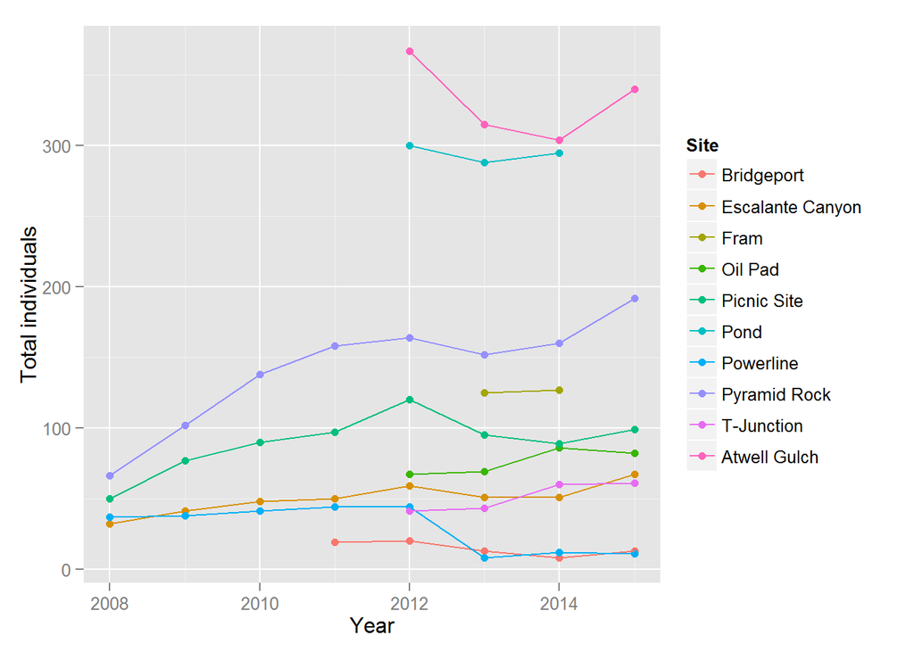

```r
ggplot(sg_sum[grep("old",sg_sum$Site,invert=TRUE),], aes(Year,X,colour=Site))+
  geom_point()+
  geom_line()+
  ylab("Total individuals")
```

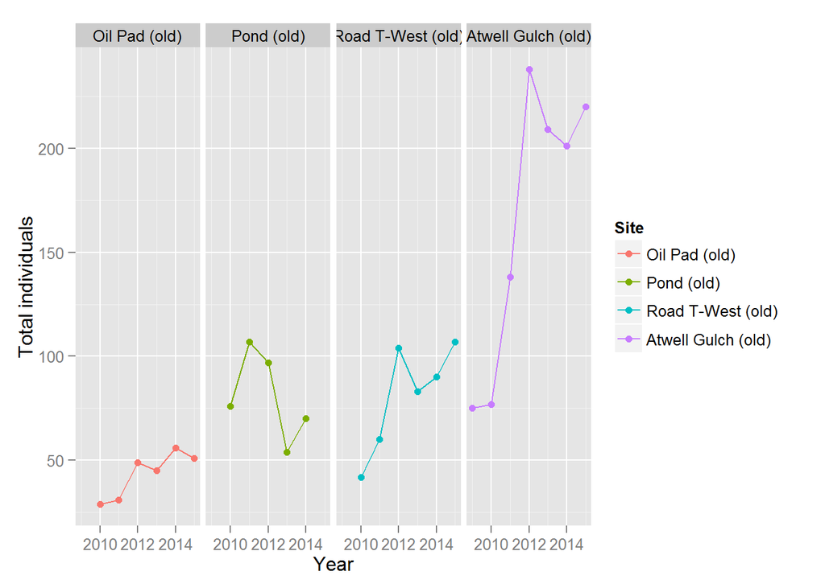

```r
# All the old ones
ggplot(sg_sum[grep("old",sg_sum$Site),], aes(Year,X,colour=Site))+
  geom_point()+
  geom_line()+
  facet_grid(~Site)+
  ylab("Total individuals")
```

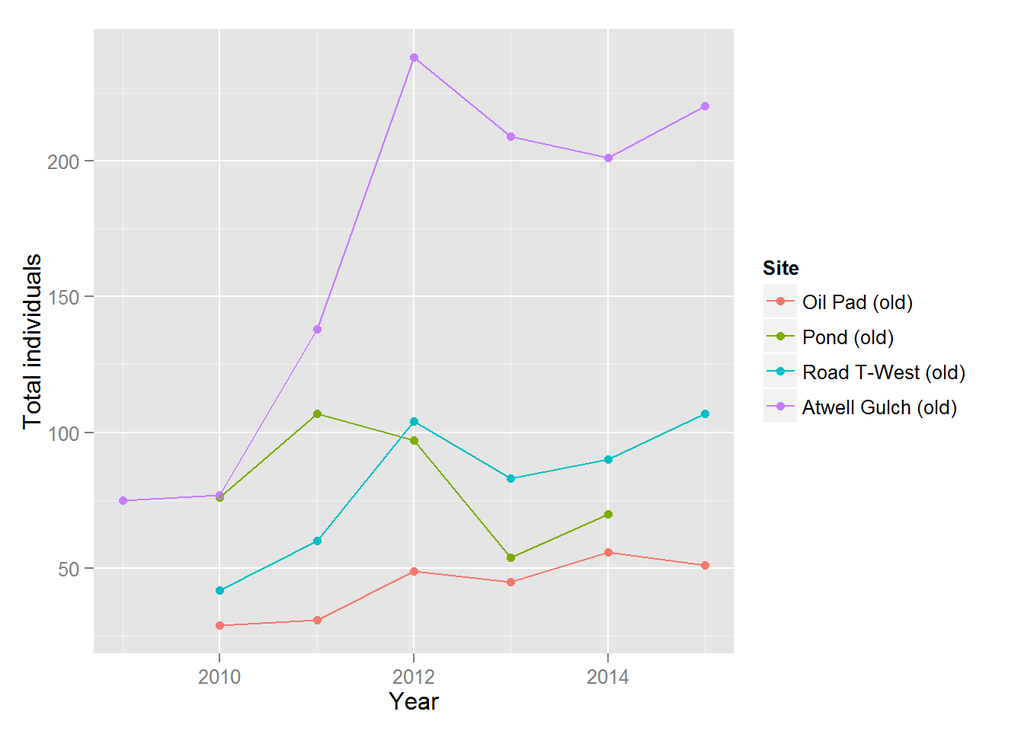

```r
ggplot(sg_sum[grep("old",sg_sum$Site),], aes(Year,X,colour=Site))+
  geom_point()+
  geom_line()+
  ylab("Total individuals")
```

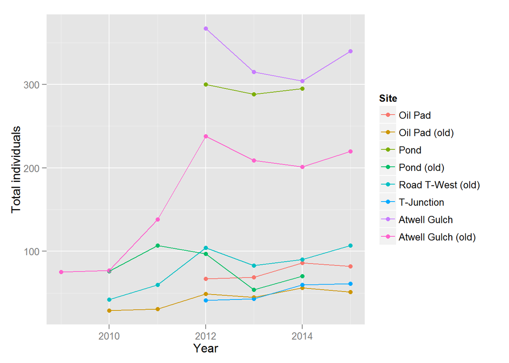

```r
# old and new
oldnew <- c("Oil","Pond","T-","Atwell")

ggplot(sg_sum[sg_sum$Site %in% unique(grep(paste(oldnew,collapse="|"),
                   sg_sum$Site, value=TRUE)),], aes(Year,X,colour=Site))+
  geom_point()+
  geom_line()+
  ylab("Total individuals")
```

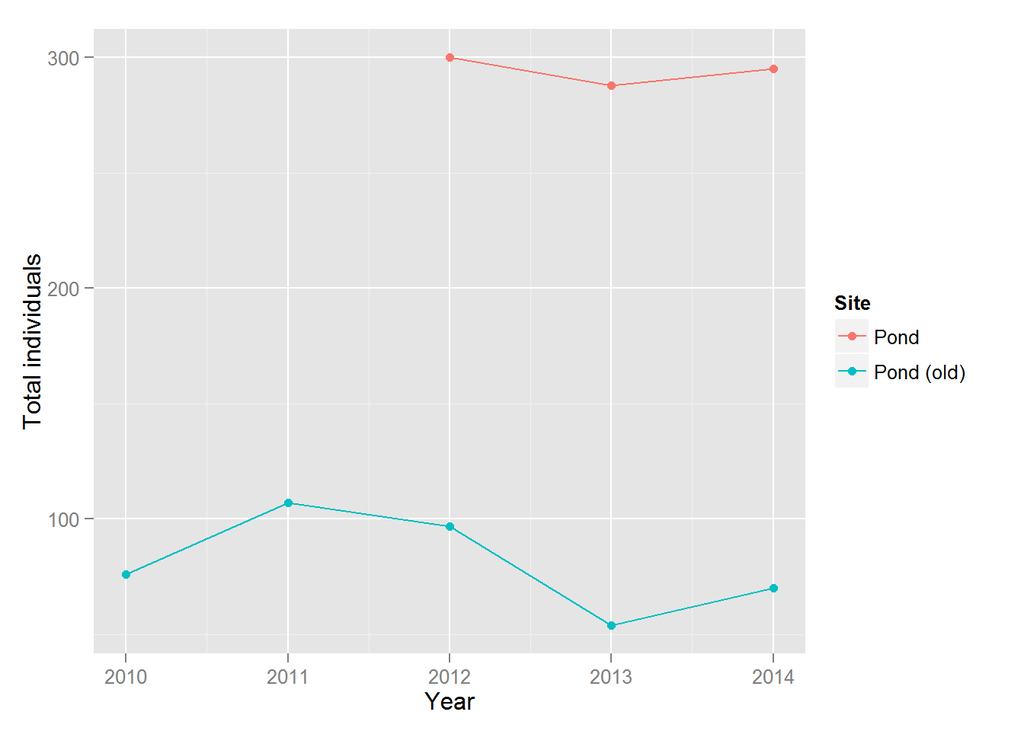

```r
#Pond
oldnew <- c("Pond")

ggplot(sg_sum[sg_sum$Site %in% unique(grep(paste(oldnew,collapse="|"),
                   sg_sum$Site, value=TRUE)),], aes(Year,X,colour=Site))+
  geom_point()+
  geom_line()+
  ylab("Total individuals")
```

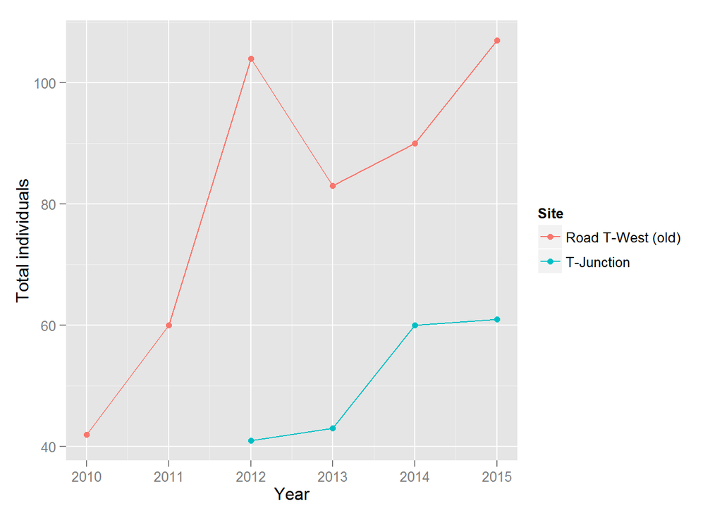

```r
# Is T-Junction missing some - should be finding more individuals
#T-Junction
oldnew <- c("T-")

ggplot(sg_sum[sg_sum$Site %in% unique(grep(paste(oldnew,collapse="|"),
                   sg_sum$Site, value=TRUE)),], aes(Year,X,colour=Site))+
  geom_point()+
  geom_line()+
  ylab("Total individuals")
```

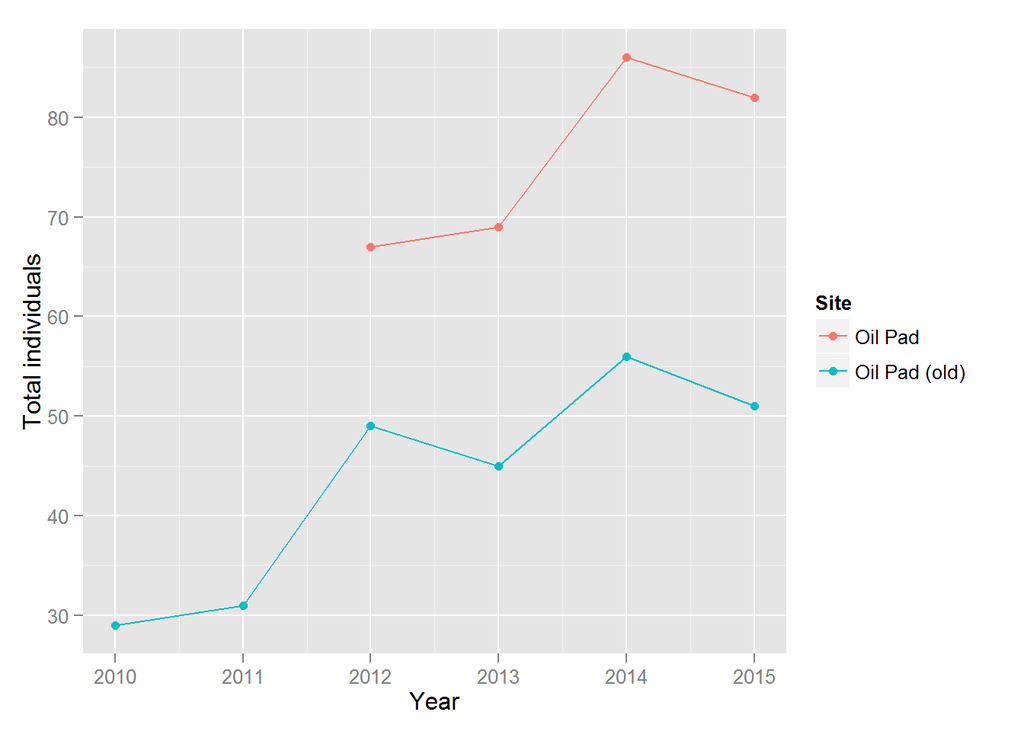

```r
#Oil Pad
oldnew <- c("Oil")

ggplot(sg_sum[sg_sum$Site %in% unique(grep(paste(oldnew,collapse="|"),
                   sg_sum$Site, value=TRUE)),], aes(Year,X,colour=Site))+
  geom_point()+
  geom_line()+
  ylab("Total individuals")
```

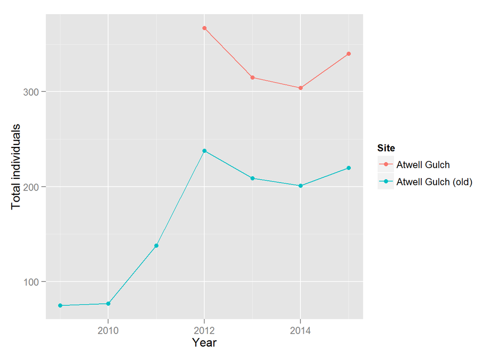

```r
#Atwell
oldnew <- c("Atwell")

ggplot(sg_sum[sg_sum$Site %in% unique(grep(paste(oldnew,collapse="|"),
                   sg_sum$Site, value=TRUE)),], aes(Year,X,colour=Site))+
  geom_point()+
  geom_line()+
  ylab("Total individuals")
```

#### Need to update once data export is fixed!!

Report Tables_2015 Table 2: Summary data of Sclerocactus glaucus demographic monitoring in western Colorado (2008 – 2015).

```r
#save into excel sheet
sg_sum[sg_sum$Year == 2015,]
```

```
##                  Site Year   X Rep Brs     avgH      sdH     avgW      sdW
## 5          Bridgeport 2015  13   3   0 3.323077 1.151921 2.869231 1.567580
## 13   Escalante Canyon 2015  67  20   6 2.237313 1.318038 3.058462 1.974912
## 19            Oil Pad 2015  82  38   1 5.956098 4.096885 4.821951 3.286336
## 25      Oil Pad (old) 2015  51  28   0 6.705882 3.853020 5.670588 3.082875
## 33        Picnic Site 2015  99  18   9 1.876768 1.117744 2.370707 1.757796
## 51          Powerline 2015  11   5   0 3.481818 1.497877 4.390909 2.255861
## 59       Pyramid Rock 2015 192  96   0 3.038021 1.496965 4.186458 2.095251
## 65  Road T-West (old) 2015 107  28   0 4.585047 3.943512 4.014953 2.745659
## 69         T-Junction 2015  61  17   0 4.637705 3.771656 4.116393 2.830558
## 73       Atwell Gulch 2015 340 131   7 3.150294 2.387313 3.750441 2.749206
## 80 Atwell Gulch (old) 2015 220  79   6 2.886364 2.169569 3.603864 2.792725
##       avgVol     sdVol
## 5   52.28828  109.6078
## 13  80.14278  184.4539
## 19 681.60109 1351.0237
## 25 966.16344 1668.5975
## 33  48.85214  158.6156
## 51  72.28303  236.4445
## 59 240.92202  312.0404
## 65 273.59048  858.8441
## 69 268.96402  765.6644
## 73 276.02366  582.4556
## 80 249.33760  550.1921
```

Climate data from PRISM http://prism.oregonstate.edu/explorer/

```r
at.cli<-read.csv(path.expand("Q:/Research/All_Projects_by_Species/Sclerocactus SPECIES/Sclerocactus_glaucus/R_code_ScGl/R_tables/Atwell_PRISM_2015.csv"),skip=6)
br.cli<-read.csv(path.expand("Q:/Research/All_Projects_by_Species/Sclerocactus SPECIES/Sclerocactus_glaucus/R_code_ScGl/R_tables/Bridgeport_PRISM_2015.csv"),skip=6)
es.cli<-read.csv(path.expand("Q:/Research/All_Projects_by_Species/Sclerocactus SPECIES/Sclerocactus_glaucus/R_code_ScGl/R_tables/Escalante_PRISM_2015.csv"),skip=6)
fr.cli<-read.csv(path.expand("Q:/Research/All_Projects_by_Species/Sclerocactus SPECIES/Sclerocactus_glaucus/R_code_ScGl/R_tables/Fram_PRISM_2015.csv"),skip=6)
op.cli<-read.csv(path.expand("Q:/Research/All_Projects_by_Species/Sclerocactus SPECIES/Sclerocactus_glaucus/R_code_ScGl/R_tables/OilPad_PRISM_2015.csv"),skip=6)
pic.cli<-read.csv(path.expand("Q:/Research/All_Projects_by_Species/Sclerocactus SPECIES/Sclerocactus_glaucus/R_code_ScGl/R_tables/Picnic_PRISM_2015.csv"),skip=6)
power.cli<-read.csv(path.expand("Q:/Research/All_Projects_by_Species/Sclerocactus SPECIES/Sclerocactus_glaucus/R_code_ScGl/R_tables/Powerline_PRISM_2015.csv"),skip=6)
pond.cli<-read.csv(path.expand("Q:/Research/All_Projects_by_Species/Sclerocactus SPECIES/Sclerocactus_glaucus/R_code_ScGl/R_tables/Pond_PRISM_2015.csv"),skip=6)
pr.cli<-read.csv(path.expand("Q:/Research/All_Projects_by_Species/Sclerocactus SPECIES/Sclerocactus_glaucus/R_code_ScGl/R_tables/PyramidRock_PRISM_2015.csv"),skip=6)
tj.cli<-read.csv(path.expand("Q:/Research/All_Projects_by_Species/Sclerocactus SPECIES/Sclerocactus_glaucus/R_code_ScGl/R_tables/TJunction_PRISM_2015.csv"),skip=6)

at.cli<-data.frame(Site="Atwell Gulch",at.cli)
br.cli<-data.frame(Site="Bridgeport",br.cli)
es.cli<-data.frame(Site="Escalante Canyon",es.cli)
fr.cli<-data.frame(Site="Fram",fr.cli)
op.cli<-data.frame(Site="Oil Pad",op.cli)
pic.cli<-data.frame(Site="Picnic Site",pic.cli)
power.cli<-data.frame(Site="Powerline",power.cli)
pond.cli<-data.frame(Site="Pond",pond.cli)
pr.cli<-data.frame(Site="Pyramid Rock",pr.cli)
tj.cli<-data.frame(Site="T-Junction",tj.cli)

scgl.climate <- rbind(at.cli,br.cli,es.cli,fr.cli,op.cli,pic.cli,power.cli,pond.cli,pr.cli,tj.cli)
scgl.climate$Year <- substr(scgl.climate$Date,1,4)
scgl.climate$Month <- substr(scgl.climate$Date,6,7)

scgl.c <- scgl.climate[,c(1,3,5,7:9)]
names(scgl.c) <- c("Site","Precip","tmin","tmax","Year","Month")
```

#### Summarize climate data

Climate of the previous 12 month to the May data collection

```r
scgl.c$Month <- as.numeric(scgl.c$Month)
scgl.c$Year <- as.numeric(scgl.c$Year)

#Months after data collection to be assigned to next year
#Add a column to assign the year from May to the previous 12 months: Jun:May
scgl.c$Prev12 <-scgl.c$Year
#Months June through December go to the next year
scgl.c[scgl.c$Month > 5,"Prev12"] <- scgl.c[scgl.c$Month > 5,"Year"]+1

scgl.c[scgl.c$Prev12 >2014,]
```

```
##                   Site Precip tmin tmax Year Month Prev12
## 1434      Atwell Gulch   3.18 10.2 28.2 2014     6   2015
## 1435      Atwell Gulch  39.03 15.1 32.4 2014     7   2015
## 1436      Atwell Gulch  68.31 12.7 27.8 2014     8   2015
## 1437      Atwell Gulch  65.66 10.0 26.7 2014     9   2015
## 1438      Atwell Gulch  20.25  3.1 19.3 2014    10   2015
## 1439      Atwell Gulch  14.45 -5.0  9.6 2014    11   2015
## 1440      Atwell Gulch  25.37 -5.7  5.1 2014    12   2015
## 1441      Atwell Gulch  17.74 -7.6  5.0 2015     1   2015
## 1442      Atwell Gulch  12.47 -3.7 10.3 2015     2   2015
## 1443      Atwell Gulch  15.47 -0.4 15.9 2015     3   2015
## 1444      Atwell Gulch  41.08  1.4 16.7 2015     4   2015
## 1445      Atwell Gulch  80.01  5.9 19.3 2015     5   2015
## 1446      Atwell Gulch  28.38 12.5 29.7 2015     6   2016
## 1447      Atwell Gulch  52.79 13.6 29.4 2015     7   2016
```

[output cut: 144 more lines]

### PCA for climate factors

calculate seasonal climate averages  
summer: June-August (6-8) fall: September-November (9-11) winter: December-February (12, 1-2) spring: March-May (3-5)

```r
scgl.c$season <- "winter"
scgl.c[scgl.c$Month>5 & scgl.c$Month<9, "season"] <- "summer"
scgl.c[scgl.c$Month>8 & scgl.c$Month<12, "season"] <- "fall"
scgl.c[scgl.c$Month>2 & scgl.c$Month<6, "season"] <- "spring"

scgl.c.summary <- aggregate(scgl.c[,2:4], scgl.c[,c("Site","Prev12","season")],
                            FUN = function(x) mean(x, na.rm = TRUE))

season <- reshape(scgl.c.summary[scgl.c.summary$Prev12<2016,],
                  idvar = c("Site","Prev12"),
                  timevar = "season",
                  direction = "wide")
```

summarySE function borrowed from http://www.cookbook-r.com/Manipulating_data/Summarizing_data/

```r
summarySE <- function(data=NULL, measurevar, groupvars=NULL, na.rm=FALSE,
                      conf.interval=.95, .drop=TRUE) {
    library(plyr)

    # New version of length which can handle NA's: if na.rm==T, don't count them
    length2 <- function (x, na.rm=FALSE) {
        if (na.rm) sum(!is.na(x))
        else       length(x)
    }

    # This does the summary. For each group's data frame, return a vector with
    # N, mean, and sd
    datac <- ddply(data, groupvars, .drop=.drop,
      .fun = function(xx, col) {
        c(N    = length2(xx[[col]], na.rm=na.rm),
          mean = mean   (xx[[col]], na.rm=na.rm),
          sd   = sd     (xx[[col]], na.rm=na.rm)
        )
      },
      measurevar
    )

    # Rename the "mean" column
    datac <- rename(datac, c("mean" = measurevar))

    datac$se <- datac$sd / sqrt(datac$N)  # Calculate standard error of the mean

    # Confidence interval multiplier for standard error
    # Calculate t-statistic for confidence interval:
    # e.g., if conf.interval is .95, use .975 (above/below), and use df=N-1
    ciMult <- qt(conf.interval/2 + .5, datac$N-1)
    datac$ci <- datac$se * ciMult

    return(datac)
}
```

summary statistics

```r
scgl_sumSE <- lapply(names(scgl.c[,c("Precip","tmin", "tmax")]),
                     function(x){
                       summarySE(scgl.c, measurevar=x, groupvars=c("Site","Prev12"))
                       })

head(scgl_sumSE[[1]])
```

```
##           Site Prev12  N   Precip       sd       se        ci
## 1 Atwell Gulch   1895  5 29.83400 15.36370 6.870855 19.076551
## 2 Atwell Gulch   1896 12 24.78333 11.05314 3.190767  7.022830
## 3 Atwell Gulch   1897 12 29.04667 13.87690 4.005917  8.816963
## 4 Atwell Gulch   1898 12 29.26167 15.65445 4.519050  9.946362
## 5 Atwell Gulch   1899 12 20.88917 10.75327 3.104201  6.832301
## 6 Atwell Gulch   1900 12 26.71667 19.23471 5.552582 12.221151
```

```r
str(scgl_sumSE[[1]])
```

```
## 'data.frame':    1220 obs. of  7 variables:
##  $ Site  : Factor w/ 10 levels "Atwell Gulch",..: 1 1 1 1 1 1 1 1 1 1 ...
##  $ Prev12: num  1895 1896 1897 1898 1899 ...
##  $ N     : num  5 12 12 12 12 12 12 12 12 12 ...
##  $ Precip: num  29.8 24.8 29 29.3 20.9 ...
##  $ sd    : num  15.4 11.1 13.9 15.7 10.8 ...
##  $ se    : num  6.87 3.19 4.01 4.52 3.1 ...
##  $ ci    : num  19.08 7.02 8.82 9.95 6.83 ...
```

```r
names(scgl_sumSE[[1]])
```

```
## [1] "Site"   "Prev12" "N"      "Precip" "sd"     "se"     "ci"
```

```r
scgl_sumSE[[1]][scgl_sumSE[[1]]$Prev12>2000,]
```

```
##                  Site Prev12  N   Precip        sd       se        ci
## 107      Atwell Gulch   2001 12 23.26667  7.016582 2.025513  4.458124
## 108      Atwell Gulch   2002 12 20.76083 14.986842 4.326329  9.522185
## 109      Atwell Gulch   2003 12 27.27750 18.597518 5.368641 11.816299
## 110      Atwell Gulch   2004 12 23.01833 20.804033 6.005607 13.218252
## 111      Atwell Gulch   2005 12 29.85833 20.411150 5.892192 12.968626
## 112      Atwell Gulch   2006 12 31.62583 25.220725 7.280596 16.024484
## 113      Atwell Gulch   2007 12 30.86417 22.175105 6.401402 14.089390
## 114      Atwell Gulch   2008 12 32.49250 18.734068 5.408060 11.903059
## 115      Atwell Gulch   2009 12 22.97333  9.068917 2.617971  5.762115
## 116      Atwell Gulch   2010 12 24.41167 11.883772 3.430549  7.550588
## 117      Atwell Gulch   2011 12 31.29083 15.270495 4.408212  9.702410
## 118      Atwell Gulch   2012 12 22.26917 13.402412 3.868943  8.515486
## 119      Atwell Gulch   2013 12 24.62833 11.658535 3.365529  7.407480
## 120      Atwell Gulch   2014 12 35.09833 22.615302 6.528475 14.369077
```

[output cut: 146 more lines]

Precipitation per site

```
## ymax not defined: adjusting position using y instead
```

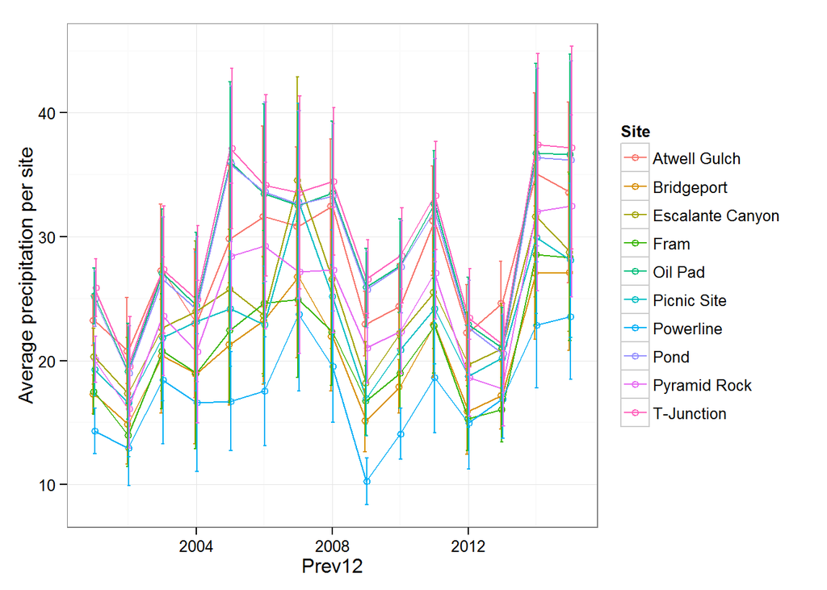

```r
ggplot(scgl_sumSE[[1]][scgl_sumSE[[1]]$Prev12>2000&
                         scgl_sumSE[[1]]$Prev12<2016,],
       aes(Prev12, Precip, colour=Site))+
  geom_point(position=position_dodge(0.1), shape=21, fill="white") +
  stat_summary(fun.y = function(x) mean(x, na.rm = TRUE), geom="line") +
  geom_errorbar(aes(ymin=Precip-se, ymax=Precip+se),width=1, position = position_dodge(0.1)) +
  theme_bw() +
  ylab("Average precipitation per site")
```

Minimum temperature per site (Celcius)

```
## ymax not defined: adjusting position using y instead
```

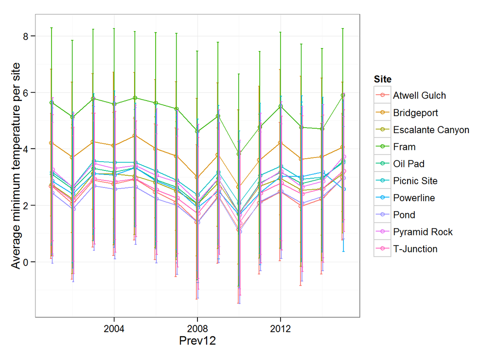

```r
ggplot(scgl_sumSE[[2]][scgl_sumSE[[2]]$Prev12>2000&
                         scgl_sumSE[[2]]$Prev12<2016,],
       aes(Prev12, tmin, colour=Site))+
  geom_point(position=position_dodge(0.1), shape=21, fill="white") +
  stat_summary(fun.y = function(x) mean(x, na.rm = TRUE), geom="line") +
  geom_errorbar(aes(ymin=tmin-se, ymax=tmin+se),width=1, position = position_dodge(0.1)) +
  theme_bw() +
  ylab("Average minimum temperature per site")
```

Maximum temperature per site (C)

```
## ymax not defined: adjusting position using y instead
```

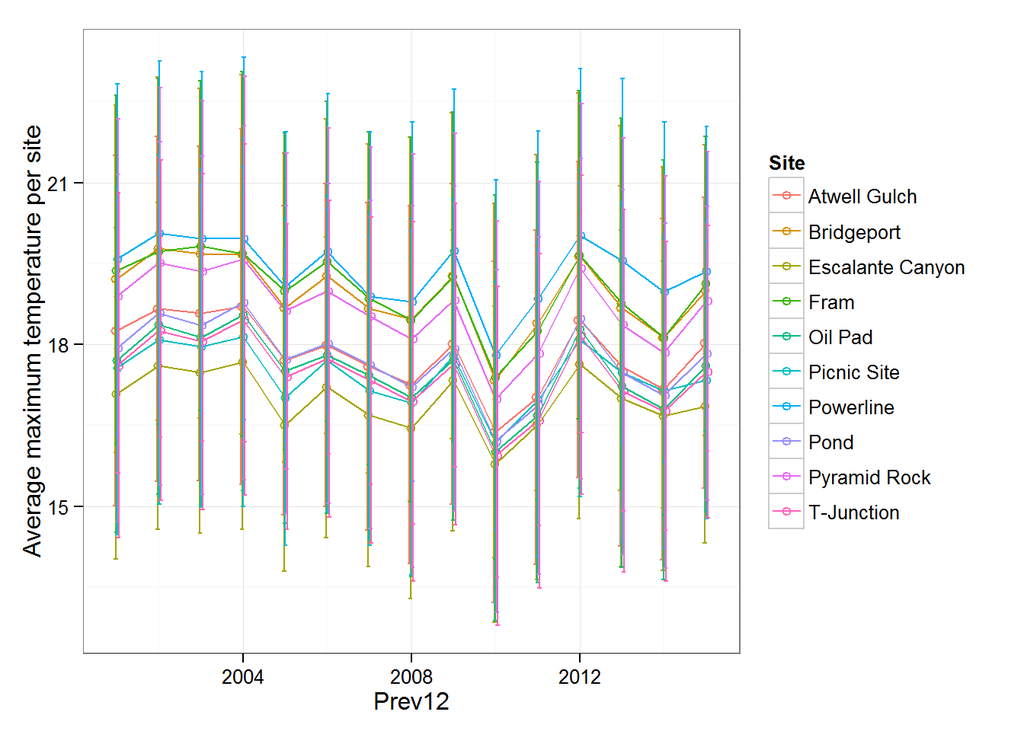

```r
ggplot(scgl_sumSE[[3]][scgl_sumSE[[3]]$Prev12>2000&
                         scgl_sumSE[[3]]$Prev12<2016,],
       aes(Prev12, tmax, colour=Site))+
  geom_point(position=position_dodge(0.1), shape=21, fill="white") +
  stat_summary(fun.y = function(x) mean(x, na.rm = TRUE), geom="line") +
  geom_errorbar(aes(ymin=tmax-se, ymax=tmax+se),width=1, position = position_dodge(0.1)) +
  theme_bw() +
  ylab("Average maximum temperature per site")
```

```r
head(season)
```

```
##               Site Prev12 Precip.fall tmin.fall tmax.fall Precip.spring
## 1     Atwell Gulch   1896    33.24333  0.600000  18.56667     16.233333
## 2       Bridgeport   1896    24.93333  1.933333  20.50000      9.936667
## 3 Escalante Canyon   1896    27.79333  1.500000  18.53333     12.926667
## 4             Fram   1896    25.57333  2.866667  19.83333     11.623333
## 5          Oil Pad   1896    32.52667  1.000000  17.96667     19.300000
## 6      Picnic Site   1896    27.13000  1.700000  19.06667     11.680000
##   tmin.spring tmax.spring Precip.summer tmin.summer tmax.summer
## 1   0.3666667    17.16667      28.30667    10.16667    29.50000
## 2   1.7000000    19.13333      23.07000    11.76667    31.46667
## 3   0.4333333    15.96667      30.37333    10.36667    28.96667
## 4   2.5666667    19.26667      19.53000    13.10000    31.46667
## 5   0.4666667    16.56667      28.81333    10.36667    29.30000
## 6   0.7666667    16.56667      29.43667    10.63333    29.50000
##   Precip.winter tmin.winter tmax.winter
## 1      21.35000   -9.600000    5.200000
## 2      11.93000   -8.866667    5.966667
## 3      15.23333   -9.133333    5.600000
## 4      12.25667   -8.100000    5.800000
## 5      22.81000   -9.100000    5.333333
## 6      13.88000   -8.866667    5.833333
```